# Material reciclável triado por associações de catadores

## 4. Diferenças entre categorias

A distribuição das medidas entre as diferentes categorias (galpões) está ilustrada na Figura 2. As médias exatas de cada categoria podem ser consultadas na Tabela 3. A categoria com a maior média foi a de galpões alugados, e a de menor foi a de cedidos.

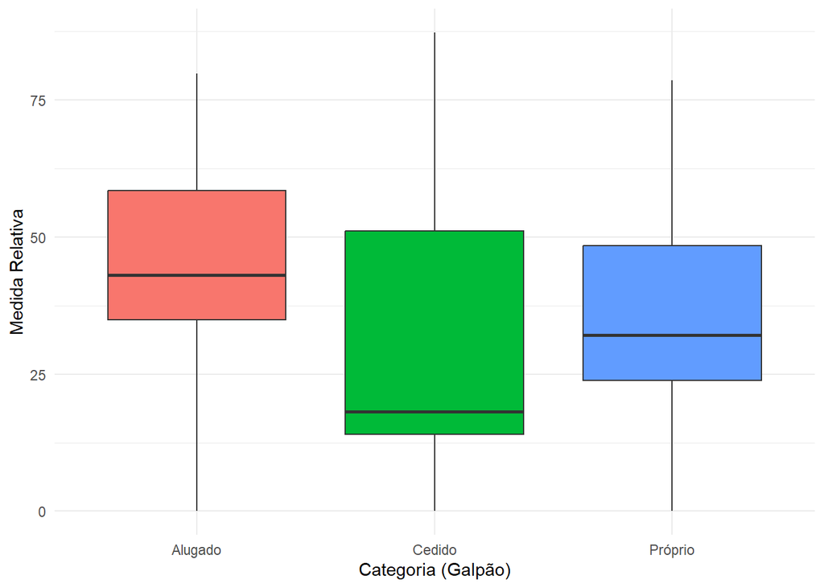

Figura 2: Distribuição da medida relativa por categoria (Boxplot).

Tabela 3: Média de coleta por categoria.

| galpao | media_mensal |
| --- | --- |
| Alugado | 46.06944 |
| Cedido | 33.66250 |
| Próprio | 35.74792 |

## 5. As tabelas da lista 3

detalhamos o desempenho individual na Tabela 4 e a visão consolidada ao longo dos anos na Tabela 5, ordenado pela média mensal.

Tabela 4: Resumo anual por unidade

| codigo | nome | galpao | meses_com_registro | total_ano | media_mensal |
| --- | --- | --- | --- | --- | --- |
| AS09 | Associação Xaxim | Cedido | 34 | 2379.0 | 66.08333 |
| AS06 | Associação São Braz | Alugado | 36 | 2288.1 | 63.55833 |
| AS05 | Associação Rebouças | Próprio | 36 | 2083.0 | 57.86111 |
| AS11 | Associação Juvevê | Alugado | 35 | 1554.6 | 43.18333 |
| AS04 | Associação Ahú | Cedido | 35 | 1430.1 | 39.72500 |
| AS01 | Associação Portão | Próprio | 36 | 1415.2 | 39.31111 |
| AS08 | Associação Pinheirinho | Alugado | 34 | 1132.8 | 31.46667 |
| AS07 | Associação Cabral | Próprio | 35 | 899.5 | 24.98611 |
| AS10 | Associação Lindóia | Próprio | 33 | 750.0 | 20.83333 |
| AS12 | Associação Água Verde | Cedido | 36 | 578.3 | 16.06389 |
| AS03 | Associação Umbará | Cedido | 36 | 460.0 | 12.77778 |

Tabela 5: Total por Categoria e Ano

| galpao | 2023 | 2024 | 2025 |
| --- | --- | --- | --- |
| Alugado | 1638.1 | 1657.8 | 1679.6 |
| Cedido | 1648.7 | 1537.3 | 1661.4 |
| Próprio | 1676.3 | 1719.5 | 1751.9 |

## 6. Diferença entre categorias

por fim, a diferença entre as categorias em relação aos anos.

Tabela 6: Resumo por Categoria (Galpão)

| galpao | qtd_unidades | total_ano | media_mensal |
| --- | --- | --- | --- |
| Alugado | 3 | 4975.5 | 46.06944 |
| Cedido | 4 | 4847.4 | 33.66250 |
| Próprio | 4 | 5147.7 | 35.74792 |